# sentiment_analysis

GuillermoSchneider

2024-03-08

# **PROJECT 3: Guillermo Schneider, Richie Rivera, Lucas Weyrich, Jonathan Cruz**

### Summary:

Search through reddit comments Search for comments that include Skills see what positive or negative words are around in those comments average sentiment score for each Skill sentiment analysis over time

```r
#install.packages("tidytext")
#install.packages("textdata")
#install.packages("tidyverse")
#install.packages("wordcloud")
#install.packages("datawizard")
library(tidytext)
library(textdata)
library(tidyverse)
library(wordcloud)
library(caret)
library(datawizard)
```

## https://www.tidytextmining.com/sentiment

### GRABBING SENTIMENT LABELED DICTIONARIES

**AFINN from Finn Årup Nielsen**

```r
afinn <- get_sentiments("afinn")
```

**bing from Bing Liu and collaborators**

```r
bing <- get_sentiments("bing")
```

**nrc from Saif Mohammad and Peter Turney**

```r
nrc <- get_sentiments("nrc")
```

```r
afinn_nrc_sentiments <- afinn %>%
  inner_join(nrc)
```

### SCRAPING THANKS TO LUCAS

**sample of 8000 posts from lucas**

```r
test_scrape <- read.csv("https://raw.githubusercontent.com/GuillermoCharlesSchneider/DATA-607/main/Project-3/test_scrape.csv")
```

**full 125k posts from lucas**

```r
full_scrape <- read.csv("https://raw.githubusercontent.com/riverar9/cuny-msds-project-3/main/part_2/reddit%20scrape.csv")
```

## UPDATED SKILLS

**Skills provided by jon:**

```r
Skills <- read.csv("https://raw.githubusercontent.com/GuillermoCharlesSchneider/DATA-607/main/Project-3/skills.csv")
```

**separate skills into single words, while still keeping the general skill bucket**

```r
Skills$word <- tolower(Skills$Skills)

Skills_single_word <- Skills %>%
  unnest_tokens(word, word)

Skills_single_word <- Skills_single_word[-c(4,9,10,11,20,21,22,23,25,28,31,40,41,42,43,46,48,50,55,57,62,65,67,71,72,75,80,83,84,92,99,136,140,141,146,147,148,150,151,152,153,154), ]
row.names(Skills_single_word) <- 1:nrow(Skills_single_word)
```

**TWO WORD SKILLS MERGED INTO ONE and trimmed (ex:data science -> datascience), multiple words per bucket. this is a stupid method, but i was too tired to figure out a new function, and i needed to look through them all anyway to see which needed to be combined and which didnt:**

```r
for(x in c(1,5,10,13,21,24,23,26,29,35,37,39,42,46,48,50,56,60,59,64,63,66,73,72,75,77,80,79,82,84,86,91,93,98,97,102,101,100,106,108,110)){
  Skills_single_word$word[x] <- paste(Skills_single_word$word[x],Skills_single_word$word[x+1],sep = "")
}

Skills_single_word <- Skills_single_word[-c(2,6,11,14,17,18,22,25,24,27,30,36,38,40,43,47,49,51,57,61,60,65,64,67,74,73,76,78,81,80,83,85,87,90,92,94,99,98,103,102,101,107,109,111), ]
row.names(Skills_single_word) <- 1:nrow(Skills_single_word)
```

```r
write.csv(Skills_single_word, "Updated_Skills.csv", row.names=FALSE)
```

## MERGED 2 WORD SKILLS (ex: data science -> datascience) IN SCRAPED REDDIT COMMENTS

### **TEST SCRAPE 8k**

```r
test_scrape$comment <- tolower(test_scrape$comment)
```

**test 8k data, once again im sure we could write a function, but ive already commited to this stupid copy paste, maybe one of you can make a: gsub inputs(skills…), desired outputs (skills merged…)**

```r
test_scrape$comment <- gsub("data science", "datascience,",test_scrape$comment)
test_scrape$comment <- gsub("data analysis", "dataanalysis,",test_scrape$comment)
test_scrape$comment <- gsub("cloud databases", "clouddatabases",test_scrape$comment)
test_scrape$comment <- gsub("machine learning", "machinelearning",test_scrape$comment)
test_scrape$comment <- gsub("apache spark", "apachespark",test_scrape$comment)
test_scrape$comment <- gsub("pivot table", "pivottable",test_scrape$comment)
test_scrape$comment <- gsub("case studies", "casestudies",test_scrape$comment)
test_scrape$comment <- gsub("convolutional neuralnet works", "convolutionalneuralnetworks",test_scrape$comment)
test_scrape$comment <- gsub("data ethics", "dataethics",test_scrape$comment)
test_scrape$comment <- gsub("data collection", "datacollection,",test_scrape$comment)
test_scrape$comment <- gsub("data exploration", "dataexploration,",test_scrape$comment)
test_scrape$comment <- gsub("artificial intelligence", "artificialintelligence,",test_scrape$comment)
test_scrape$comment <- gsub("machine learning", "machinelearning,",test_scrape$comment)

#ive started to regret it about here
test_scrape$comment <- gsub("ask questions", "askquestions,",test_scrape$comment)
test_scrape$comment <- gsub("data driven", "datadriven",test_scrape$comment)
test_scrape$comment <- gsub("big data", "bigdata",test_scrape$comment)
test_scrape$comment <- gsub("descriptive statistics", "descriptivestatistics",test_scrape$comment)
test_scrape$comment <- gsub("recurrent neural network", "recurrentneuralnetwork",test_scrape$comment)
test_scrape$comment <- gsub("deep neural networks", "deepneuralnetworks",test_scrape$comment)
test_scrape$comment <- gsub("hyper parameter tuning", "hyperparametertuning",test_scrape$comment)
test_scrape$comment <- gsub("exploratory data analysis", "exploratorydataanalysis",test_scrape$comment)
test_scrape$comment <- gsub("neural network architecture", "neuralnetworkarchitecture",test_scrape$comment)
test_scrape$comment <- gsub("regression analysis", "regressionanalysis",test_scrape$comment)
test_scrape$comment <- gsub("data aggregation", "dataaggregation",test_scrape$comment)
test_scrape$comment <- gsub("deep learning", "deeplearning",test_scrape$comment)
test_scrape$comment <- gsub("data cleansing", "datacleansing",test_scrape$comment)
test_scrape$comment <- gsub("statistical hypothesis testing", "statisticalhypothesistesting",test_scrape$comment)
test_scrape$comment <- gsub("relational database management systems", "relationaldatabasemanagementsystems",test_scrape$comment)
test_scrape$comment <- gsub("information technology", "informationtechnology",test_scrape$comment)
test_scrape$comment <- gsub("data architecture", "dataarchitecture",test_scrape$comment)
test_scrape$comment <- gsub("process data", "processdata",test_scrape$comment)
```

**separate 8000 comments into single words**

```r
tidy_test_scrape <- test_scrape %>%
  unnest_tokens(word, comment)
```

**TEST_SCRAPE: filter to just comments containing skills**

```r
TEST <- tidy_test_scrape %>%
  inner_join(Skills_single_word)
comment_ids <- distinct(TEST, X, Skills)

TEST2 <- filter(tidy_test_scrape, tidy_test_scrape$X %in% comment_ids$X)


TEST2 <- TEST2 %>%
  left_join(afinn)
TEST2 <- TEST2 %>%
  left_join(bing)
TEST2 <- TEST2 %>%
  left_join(Skills_single_word)
#MEAN excluding all non sentiment words. sum of sentiment values /  number of only sentiment words
TEST3 <- TEST2 %>%
  group_by(X) %>%
  summarize(sentiment_score = mean(value,na.rm=T))

#setting each word without a sentiment, to a 0 sentiment value
TEST2$value[is.na(TEST2$value)] <- 0

#MEAN of sentiments / total words (including nonsentiments) in comment
TEST4 <- TEST2 %>%
  group_by(X) %>%
  summarize(sentiment_score = mean(value))

TEST5 <- TEST2 %>%
  group_by(X) %>%
  summarize(sentiment_score = sum(value))
```

```r
write.csv(tidy_test_scrape, "tidy_test_scrape_merged.csv", row.names=FALSE)
```

### **FULL SCRAPE**

**full_scrape TO LOWER CASE**

```r
full_scrape$comment <- tolower(full_scrape$comment)
```

**CLEANING TWO WORDS TO ONE. once again no function… zzz**

```r
full_scrape$comment <- gsub("data science", "datascience,",full_scrape$comment)
full_scrape$comment <- gsub("data analysis", "dataanalysis,",full_scrape$comment)
full_scrape$comment <- gsub("cloud databases", "clouddatabases",full_scrape$comment)
full_scrape$comment <- gsub("machine learning", "machinelearning",full_scrape$comment)
full_scrape$comment <- gsub("apache spark", "apachespark",full_scrape$comment)
full_scrape$comment <- gsub("pivot table", "pivottable",full_scrape$comment)
full_scrape$comment <- gsub("case studies", "casestudies",full_scrape$comment)
full_scrape$comment <- gsub("convolutional neuralnet works", "convolutionalneuralnetworks",full_scrape$comment)
full_scrape$comment <- gsub("data ethics", "dataethics",full_scrape$comment)
full_scrape$comment <- gsub("data collection", "datacollection,",full_scrape$comment)
full_scrape$comment <- gsub("data exploration", "dataexploration,",full_scrape$comment)
full_scrape$comment <- gsub("artificial intelligence", "artificialintelligence,",full_scrape$comment)
full_scrape$comment <- gsub("machine learning", "machinelearning,",full_scrape$comment)

#ive started to regret it about here
full_scrape$comment <- gsub("ask questions", "askquestions,",full_scrape$comment)
full_scrape$comment <- gsub("data driven", "datadriven",full_scrape$comment)
full_scrape$comment <- gsub("big data", "bigdata",full_scrape$comment)
full_scrape$comment <- gsub("descriptive statistics", "descriptivestatistics",full_scrape$comment)
full_scrape$comment <- gsub("recurrent neural network", "recurrentneuralnetwork",full_scrape$comment)
full_scrape$comment <- gsub("deep neural networks", "deepneuralnetworks",full_scrape$comment)
full_scrape$comment <- gsub("hyper parameter tuning", "hyperparametertuning",full_scrape$comment)
full_scrape$comment <- gsub("exploratory data analysis", "exploratorydataanalysis",full_scrape$comment)
full_scrape$comment <- gsub("neural network architecture", "neuralnetworkarchitecture",full_scrape$comment)
full_scrape$comment <- gsub("regression analysis", "regressionanalysis",full_scrape$comment)
full_scrape$comment <- gsub("data aggregation", "dataaggregation",full_scrape$comment)
full_scrape$comment <- gsub("deep learning", "deeplearning",full_scrape$comment)
full_scrape$comment <- gsub("data cleansing", "datacleansing",full_scrape$comment)
full_scrape$comment <- gsub("statistical hypothesis testing", "statisticalhypothesistesting",full_scrape$comment)
full_scrape$comment <- gsub("relational database management systems", "relationaldatabasemanagementsystems",full_scrape$comment)
full_scrape$comment <- gsub("information technology", "informationtechnology",full_scrape$comment)
full_scrape$comment <- gsub("data architecture", "dataarchitecture",full_scrape$comment)
full_scrape$comment <- gsub("process data", "processdata",full_scrape$comment)
```

**separate 125k comments into single words**

```r
tidy_full_scrape <- full_scrape %>%
  unnest_tokens(word, comment)
```

**FULL SCRAPE: FIND COMMENTS CONTAINING SKILLS**

**left join sentiments into the full scrape**

```r
sentiment_tidy_merged_full_scrape <- tidy_full_scrape %>%
  left_join(afinn)
sentiment_tidy_merged_full_scrape <- sentiment_tidy_merged_full_scrape %>%
  left_join(bing)
```

**one hot encoding is a good solution for the NRC multiple sentiments per word THANK YOU LUCAS**

```r
#nrc$word = as.factor(nrc$word)
#onehotnrc <- predict(dummyVars(" ~ .", data = nrc), newdata = nrc)
#onehotnrc = as.data.frame(onehotnrc)


#group by sentiment
#lucas will use for nrc analysis if needed

#library(caret)
#one_hot_encoded <- dummyVars("~.", data = data)
#encoded_data <- data.frame(predict(one_hot_encoded, newdata = data))
```

**CLEANED TIDIED DATASET WITH MERGED WORDS**

```r
write.csv(sentiment_tidy_merged_full_scrape, "tidy_full_scrape_merged_sentiments.csv", row.names=FALSE)
```

**count of single word Skills words in the tidied scape:**

```r
#8000 comments
tidy_test_scrape %>%
  inner_join(Skills_single_word) %>%
  count(word, sort = TRUE) %>%
  head(10)
```

```
##               word   n
## 1      datascience 797
## 2           python 441
## 3               ai 427
## 4                r 377
## 5  machinelearning 276
## 6       statistics 208
## 7              sql 185
## 8            excel 125
## 9          jupyter 119
## 10     probability  71
```

```r
#125k comments
tidy_full_scrape %>%
  inner_join(Skills_single_word) %>%
  count(word, sort = TRUE) %>%
  head(10)
```

```
##               word    n
## 1           python 9213
## 2              sql 9070
## 3      datascience 6760
## 4                r 5121
## 5               ai 3055
## 6  machinelearning 2648
## 7           pandas 2563
## 8            excel 2430
## 9         database 2297
## 10       pipelines 1995
```

**joyful words from NRC:**

```r
nrc_joy <- get_sentiments("nrc") %>%
  filter(sentiment == "joy")
```

**count of joyful words in the tidied single word scrape, matching 1 to 1 words w inner join on “word” column:**

```r
tidy_test_scrape %>%
  inner_join(nrc_joy) %>%
  count(word, sort = TRUE) %>%
  head(10)
```

```
##      word   n
## 1    good 870
## 2  pretty 278
## 3     pay 250
## 4    kind 208
## 5   money 175
## 6  salary 174
## 7    love 170
## 8    true 144
## 9   excel 125
## 10 create 121
```

**count of all single words**

```r
t <- tidy_full_scrape %>%
  count(word, sort = TRUE)
```

## **Time Series graphs (thanks LUCAS)**

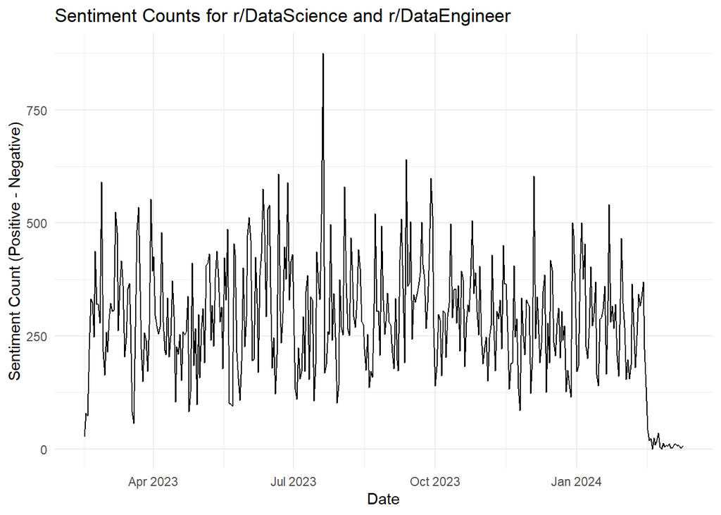

```r
library(ggplot2)
library(zoo)
sentiment_comments_containing_skills_full_scrape <- comments_containing_skills_full_scrape %>%
  left_join(afinn)
sentiment_comments_containing_skills_full_scrape <- sentiment_comments_containing_skills_full_scrape %>%
  left_join(bing)
time_series_full_scrape = sentiment_tidy_merged_full_scrape %>%
  group_by(date) %>%
  summarize(positive = sum(sentiment == "positive", na.rm = TRUE),
            negative = sum(sentiment == "negative", na.rm = TRUE)) %>%
  mutate(sentiment_value = positive - negative) %>%
  mutate(roll_avg_7 = rollmean(sentiment_value, k = 7, fill = NA)) %>%
  mutate(roll_avg_30 = rollmean(sentiment_value, k = 30, fill = NA)) %>%
  mutate(roll_avg_30_pos = rollmean(positive, k = 30, fill = NA)) %>%
  mutate(roll_avg_30_neg = rollmean(negative, k = 30, fill = NA))

time_series_skills_scrape = sentiment_comments_containing_skills_full_scrape %>%
    group_by(date) %>%
  summarize(positive = sum(sentiment == "positive", na.rm = TRUE),
            negative = sum(sentiment == "negative", na.rm = TRUE)) %>%
  mutate(sentiment_value = positive - negative) %>%
  mutate(roll_avg_7 = rollmean(sentiment_value, k = 7, fill = NA)) %>%
  mutate(roll_avg_30 = rollmean(sentiment_value, k = 30, fill = NA)) %>%
  mutate(roll_avg_30_pos = rollmean(positive, k = 30, fill = NA)) %>%
  mutate(roll_avg_30_neg = rollmean(negative, k = 30, fill = NA))

time_series_full_scrape$date = as.Date(time_series_full_scrape$date)
time_series_skills_scrape$date = as.Date(time_series_skills_scrape$date)

ggplot(aes(x = date, y = sentiment_value), data = time_series_full_scrape) +
  geom_line() +
  theme_minimal() +
  labs(x = 'Date', y = 'Sentiment Count (Positive - Negative)', title = 'Sentiment Counts for r/DataScience and r/DataEngineer')
```

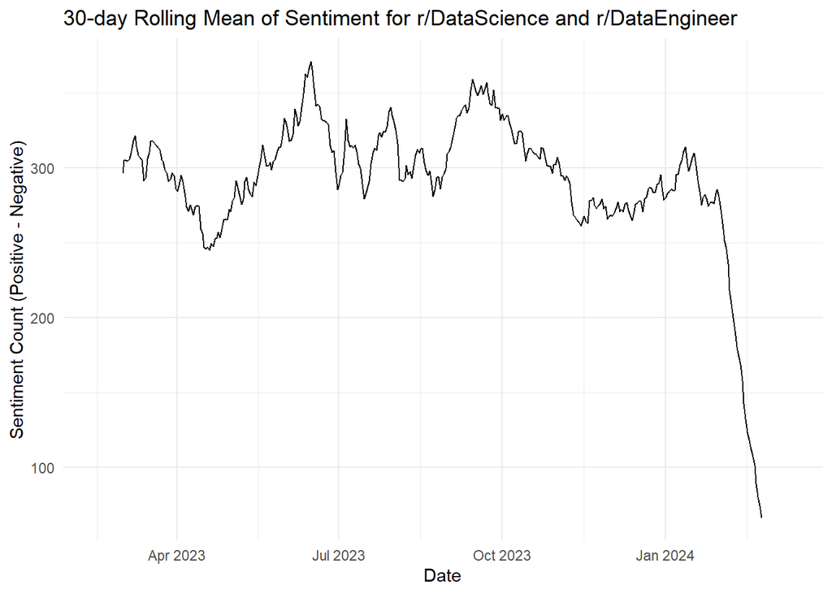

```r
ggplot(aes(x = date, y = roll_avg_30), data = time_series_full_scrape) +
  geom_line() +
  theme_minimal() +
  labs(x = 'Date', y = 'Sentiment Count (Positive - Negative)', title = '30-day Rolling Mean of Sentiment for r/DataScience and r/DataEngineer')
```

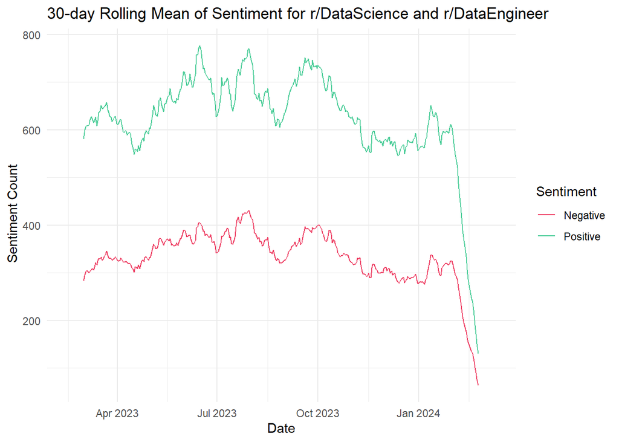

```r
ggplot(time_series_full_scrape, aes(x = date)) +
  geom_line(aes(y = roll_avg_30_pos, color = "Positive")) +
  geom_line(aes(y = roll_avg_30_neg, color = "Negative")) +
  labs(x = "Date", y = " Sentiment Count", title = "30-day Rolling Mean of Sentiment for r/DataScience and r/DataEngineer", color = "Sentiment") +
  scale_color_manual(values = c("Positive" = "#4CCD99", "Negative" = "#EE4266")) +
  theme_minimal()
```

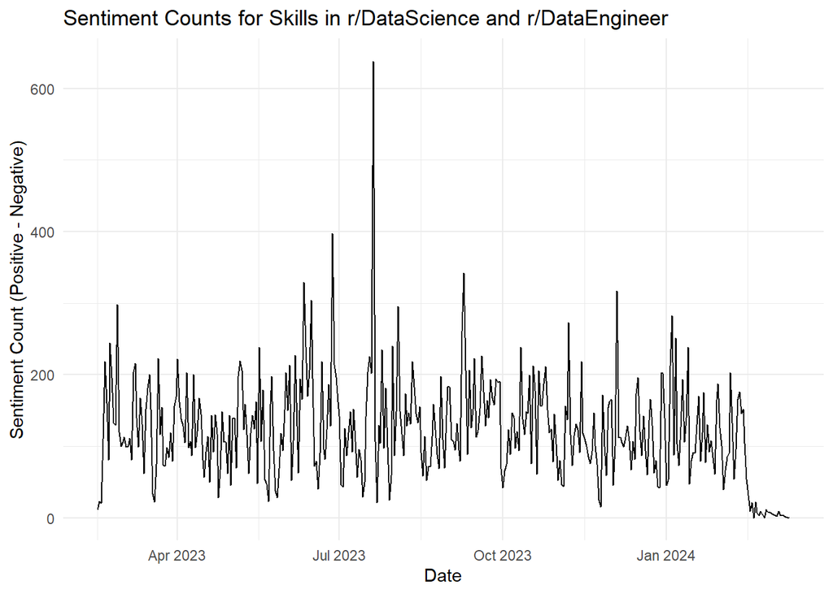

```r
ggplot(aes(x = date, y = sentiment_value), data = time_series_skills_scrape) +
  geom_line() +
  theme_minimal() +
  labs(x = 'Date', y = 'Sentiment Count (Positive - Negative)', title = 'Sentiment Counts for Skills in r/DataScience and r/DataEngineer')
```

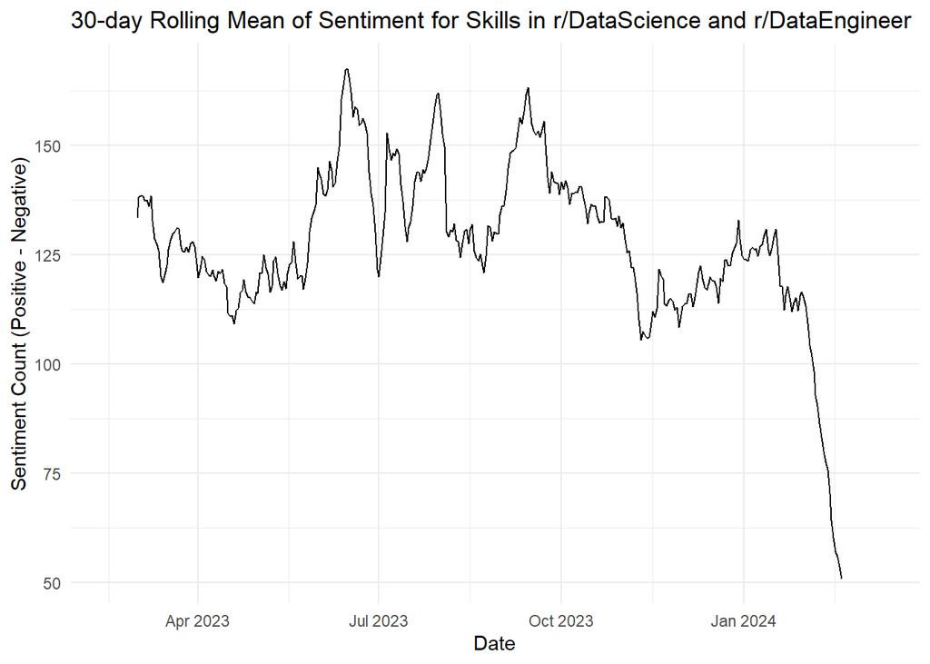

```r
ggplot(aes(x = date, y = roll_avg_30), data = time_series_skills_scrape) +
  geom_line() +
  theme_minimal() +
  labs(x = 'Date', y = 'Sentiment Count (Positive - Negative)', title = '30-day Rolling Mean of Sentiment for Skills in r/DataScience and r/DataEngineer')
```

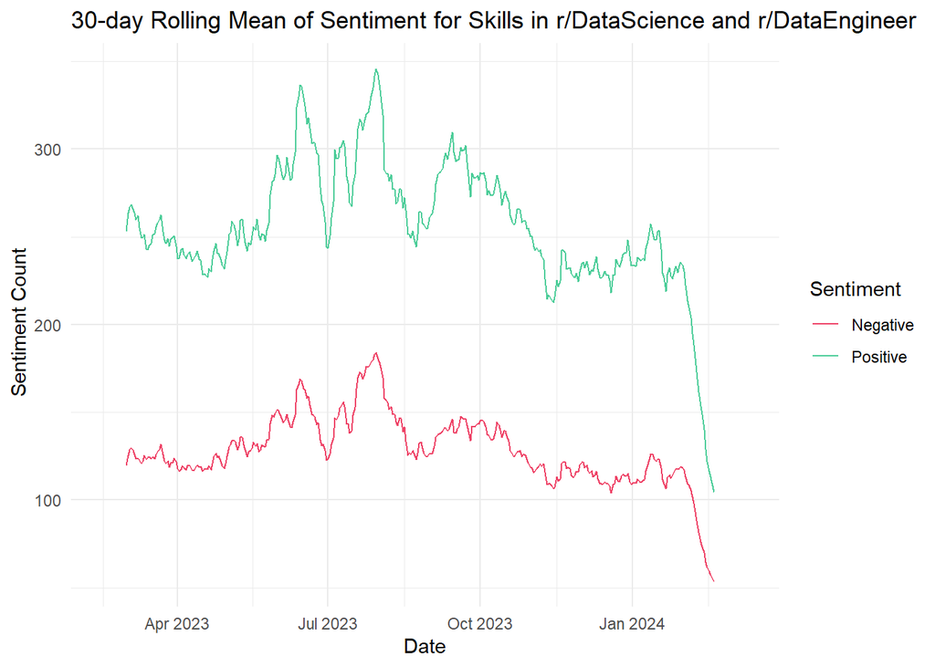

```r
ggplot(time_series_skills_scrape, aes(x = date)) +
  geom_line(aes(y = roll_avg_30_pos, color = "Positive")) +
  geom_line(aes(y = roll_avg_30_neg, color = "Negative")) +
  labs(x = "Date", y = " Sentiment Count", title = "30-day Rolling Mean of Sentiment for Skills in r/DataScience and r/DataEngineer", color = "Sentiment") +
  scale_color_manual(values = c("Positive" = "#4CCD99", "Negative" = "#EE4266")) +
  theme_minimal()
```

**potential word cloud code?**

library(wordcloud) w <- sort(rowSums(t), decreasing = TRUE) set.seed(222) wordcloud(word = word(w), freq = w, max.words = 150, random.order = F, min.freq = 5, colors = brewer.pal(8, ‘Dark2’), scale = c(5, 0.3), rot.per = 0.7)